# Unidade 1

José Aguinaldo

# 1 Analise de Sobrevivência no R

```r
rm(list=ls())             # Apagar todos objetos
# cat("\014")             # Limpar a tela (semelhante ao 'clear')
# getwd()                 # Mostra o diretório em uso
```

## 1.1 Carregar a Biblioteca

O pacote R usa as bibiotecas “survival” e “survminer” para análise dos tempos de falha e visualização dos resultados

```r
####  Instale as bibliotecas, cso não as tenha instaladas
# install.packages("survival")
# install.packages("survminer")

# if(!require(survival))  {install.packages("survival") }
# if(!require(survminer)) { install.packages("survminer")}

#### Carregar as biblioteca
library(survival)    # realização das análises
library(survminer)   # visualização dos resultados.
```

Abaixo, temos os tempos (em meses) até ocorrer o desfecho do evento estudado (óbito de paciente) para um grupo de pacientes de um estudo clínico. O símbolo “+” indica uma censurano tempo.

1, 1, 1, 1+, 4+, 5, 7, 8, 10, 10+, 12+, 16+, 16+, 16+

```r
time <- c(1,1,1,1,4,5,7,8,10,10,12,16,16,16) # tempos
status <- c(1,1,1,0,0,1,1,1,1,0,0,0,0,0)     # censura
dados <-   # cria um objeto com as falhas/censuras para usar na função survfit()
km <- survfit(Surv(time, status) ~ 1)  # usar "1" quando for um grupo apenas
km
```

```
## Call: survfit(formula = Surv(time, status) ~ 1)
##
##       n events median 0.95LCL 0.95UCL
## [1,] 14      7     10       5      NA
```

Há 14 pacientes no estudo e ocorreram 7 eventos (= mortes), então tivemos 7 (= 14 - 7) censuras. A mediana do tempo de sobrevivência foi estimada em 10 meses com um intervalo de confiança de [5, infinito) meses.

NA = indica ausência de dado “Not Available”

## 1.2 Estimativas de Kaplan-Meier de S(t)

Tabela com a estimativas de Kaplan-Meier da função de sobrevivênca, S(t), usando com suas respectivos erro-padrões e intervalos de confiança

time = tempo n.risk = pessoas sob risco em t (ainda vivos no tempo t) n.event = número de eventos em t (mortes) survival = S(t) função sobrevivência em t std.err = erro-padrão de S(t) ( = raiz quadrada da variância ) lower, upper = limites inferior e superior do intervalo de confiança para S(t)

```r
summary(km)
```

```
## Call: survfit(formula = Surv(time, status) ~ 1)
##
##  time n.risk n.event survival std.err lower 95% CI upper 95% CI
##     1     14       3    0.786   0.110        0.598        1.000
##     5      9       1    0.698   0.128        0.488        0.999
##     7      8       1    0.611   0.138        0.392        0.952
##     8      7       1    0.524   0.143        0.306        0.896
##    10      6       1    0.437   0.144        0.229        0.832
```

## 1.3 Transformação log-log

Se desejar usar a transformação log-log para melhorar a estimativa do erro-padrão e dos intervalos de confiança, use a opção “conf.type=”log-log”’ dentro do comando do surfit()

```r
km <- survfit(Surv(time, status) ~ 1, conf.type="log-log")
summary(km)
```

```
## Call: survfit(formula = Surv(time, status) ~ 1, conf.type = "log-log")
##
##  time n.risk n.event survival std.err lower 95% CI upper 95% CI
##     1     14       3    0.786   0.110        0.472        0.925
##     5      9       1    0.698   0.128        0.378        0.876
##     7      8       1    0.611   0.138        0.298        0.819
##     8      7       1    0.524   0.143        0.227        0.754
##    10      6       1    0.437   0.144        0.164        0.683
```

## 1.4 Gráfico da Função de sobrevivência

O comando plot() cria o gráfico da função sobrevivência com seus limites do intervalo de confiança. O subcomando mark.time=TRUE permite sinalizar as censuras no gráfico.

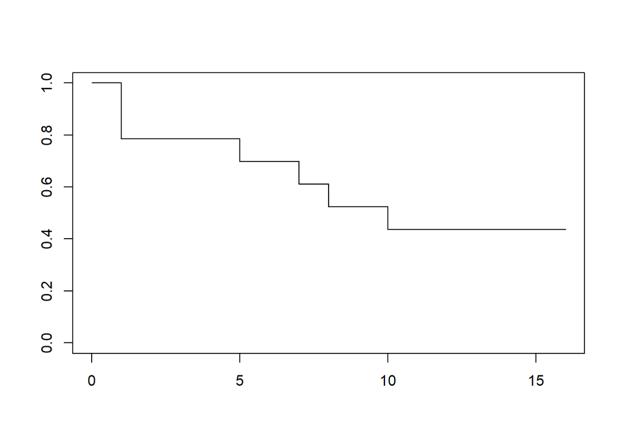

```r
plot(km, conf.int = FALSE)
```

O mesmo gráfico mostrando o intervalo de confiança e as censuras

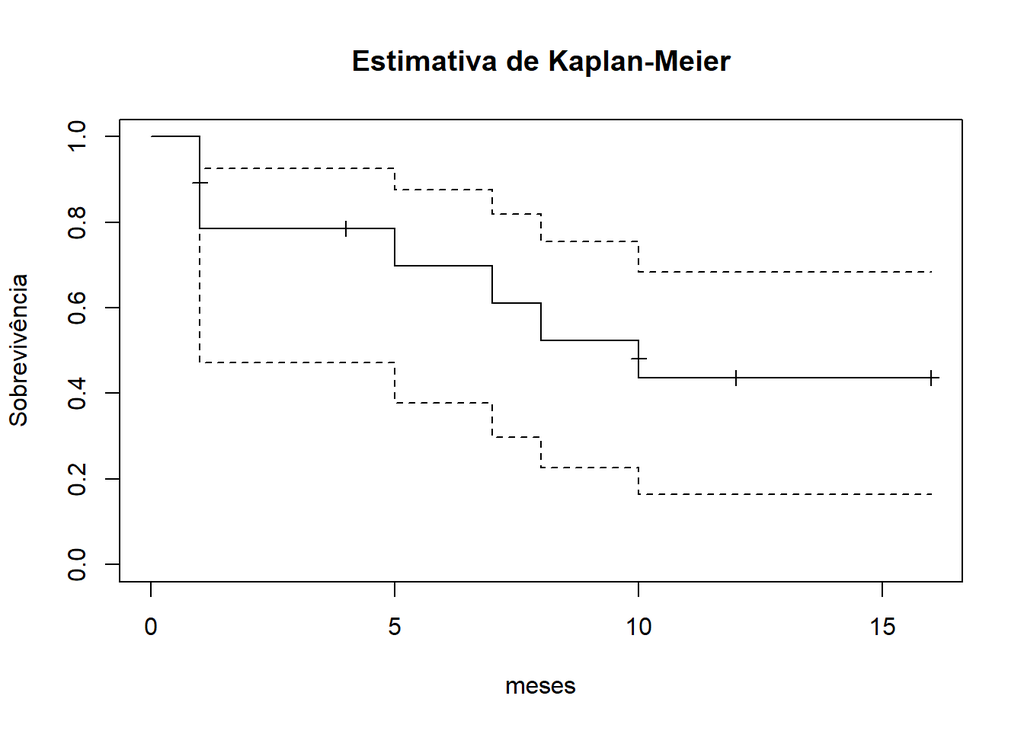

```r
plot(km, conf.int = TRUE, xlab = 'meses', ylab = 'Sobrevivência', mark.time=TRUE, main = 'Estimativa de Kaplan-Meier')
```

## 1.5 Usando o comando ggsurvlot

Os gráficos anteriores foram bem simples, pois foram usadas as funções carregadas por default no R. Esses gráficos podem ser melhorados usando o comando “ggsurplot” que usa a biblioteca “ggplpot2” que é carregada juntamente com a biblioteca “survminer”.

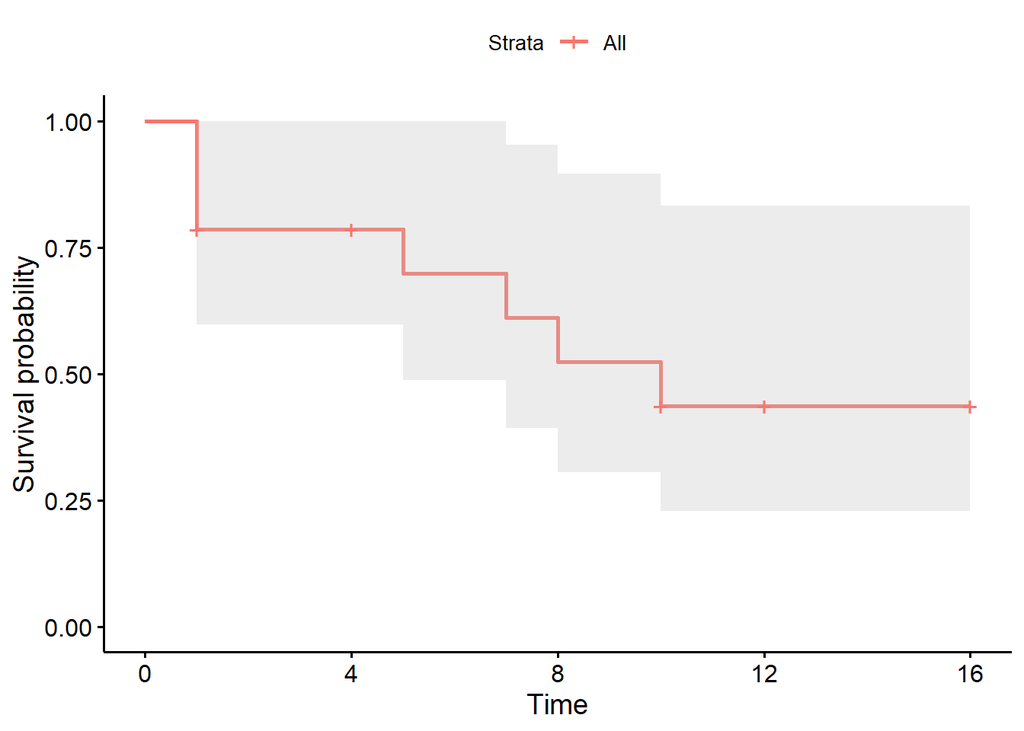

```r
# Para usar o comando 'ggsurvplot', os dados precisam estar e forma de tabela e
# isso pode ser feito usando o comando data.frame()

dados <- data.frame(time, status)
km <- survfit(Surv(time, status) ~ 1, data = dados)
ggsurvplot(km, conf.int = TRUE)  # mostrando o intervalo de confiança
```

O mesmo gráfico acima sem os limites de intervalo de confiança e agora com as informações da quantidade de pessoas sob risco no inicio do tempo e a quantidade de falhas no tempo.

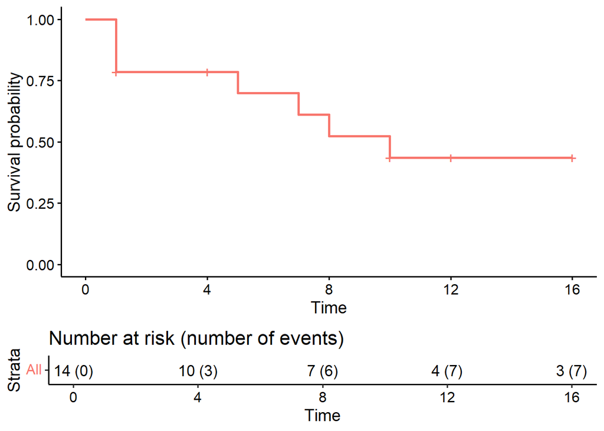

```r
ggsurvplot(km, conf.int = FALSE, risk.table = "nrisk_cumevents", legend = "none")
```